# Dang Bich Thuy Le - Chitvan Bharatkumar Patel

# Data Augmentation

#### In this lab, you will develop a data augmentation and visualization.

```python
# portions of this lab were taken from Deep Learning with Python

import glob
import os
import random
import shutil

import tensorflow as tf
from tensorflow.keras.layers import *
from tensorflow.keras.models import Model
from tensorflow.keras.optimizers import *
import tensorflow as tf
from tensorflow.keras.callbacks import ModelCheckpoint
from keras.preprocessing.image import ImageDataGenerator
from tensorflow.keras.applications import VGG16, ResNet50, MobileNetV2

import matplotlib.pyplot as plt
%matplotlib inline
```

```python
NSAMPLES = 1000

dataset_dir = "/home/tt/Downloads/dogs-vs-cats/"

train_dir = dataset_dir + "/train"

train_dogs = glob.glob(train_dir + "/dog*.*")
train_cats = glob.glob(train_dir + "/cat*.*")

sampled_train_dir = dataset_dir + "/s_train"
sampled_valid_dir = dataset_dir + "/s_valid"
sampled_test_dir = dataset_dir + "/s_test"

try:
    shutil.rmtree(sampled_train_dir)
    shutil.rmtree(sampled_valid_dir)
    shutil.rmtree(sampled_test_dir)
except:
    pass

os.makedirs(sampled_train_dir, exist_ok=True)
os.makedirs(sampled_valid_dir, exist_ok=True)
os.makedirs(sampled_test_dir, exist_ok=True)

os.makedirs(sampled_train_dir + "/dogs", exist_ok=True)
os.makedirs(sampled_train_dir + "/cats", exist_ok=True)

os.makedirs(sampled_valid_dir + "/dogs", exist_ok=True)
os.makedirs(sampled_valid_dir + "/cats", exist_ok=True)

os.makedirs(sampled_test_dir + "/dogs", exist_ok=True)
os.makedirs(sampled_test_dir + "/cats", exist_ok=True)

random.shuffle(train_dogs)
random.shuffle(train_cats)

for fn in train_dogs[0:NSAMPLES]:
    src = fn
    dst = sampled_train_dir + "/dogs/" + os.path.split(src)[-1]
    shutil.copyfile(src, dst)

for fn in train_cats[0:NSAMPLES]:
    src = fn
    dst = sampled_train_dir + "/cats/" + os.path.split(src)[-1]
    shutil.copyfile(src, dst)

for fn in train_dogs[NSAMPLES:NSAMPLES + NSAMPLES//2]:
    src = fn
    dst = sampled_valid_dir + "/dogs/" + os.path.split(src)[-1]
    shutil.copyfile(src, dst)

for fn in train_cats[NSAMPLES:NSAMPLES + NSAMPLES//2]:
    src = fn
    dst = sampled_valid_dir + "/cats/" + os.path.split(src)[-1]
    shutil.copyfile(src, dst)

for fn in train_dogs[NSAMPLES:NSAMPLES + NSAMPLES//2]:
    src = fn
    dst = sampled_test_dir + "/dogs/" + os.path.split(src)[-1]
    shutil.copyfile(src, dst)

for fn in train_cats[NSAMPLES:NSAMPLES + NSAMPLES//2]:
    src = fn
    dst = sampled_test_dir + "/cats/" + os.path.split(src)[-1]
    shutil.copyfile(src, dst)

print("... generated directories s_train, s_valid and s_test")
```

#### Now you will create a model to learn now to differentiate between cats and dogs.

```python
# no batch normalization yet, learning rate is too high, add dropout between Dense
def get_model():
    x = x_in = Input((150,150,3), name="input")
    x = Conv2D(32, (3,3), padding="valid",  name="fe0")(x)
    x = Activation("swish", name="r0")(x)
    x = MaxPooling2D(2,2,name="mp0")(x)
    x = Conv2D(64, (3,3), padding="valid", name="fe1")(x)
    x = Activation("swish", name="r1")(x)
    x = MaxPooling2D(2,2,name="mp1")(x)
    x = Conv2D(128, (3,3), padding="valid", name="fe2")(x)
    x = Activation("swish", name="r2")(x)
    x = MaxPooling2D(2,2,name="mp2")(x)
    x = Flatten(name="fl")(x)
    x = Dropout(0.5, name="d5")(x)
    x = Dense(512, name="d1", activation="swish")(x)
    x = Dense(1, name="d2")(x)
    x = Activation("sigmoid", name="s1")(x)
    m = Model(inputs=x_in, outputs=x)
    m.summary()

    return m


adam = Adam(learning_rate=0.001)

model = get_model()


model.compile(loss="binary_crossentropy", optimizer=adam, metrics=["acc"])
```

```
Model: "model_1"
_________________________________________________________________
 Layer (type)                Output Shape              Param #
=================================================================
 input (InputLayer)          [(None, 150, 150, 3)]     0

 fe0 (Conv2D)                (None, 148, 148, 32)      896

 r0 (Activation)             (None, 148, 148, 32)      0

 mp0 (MaxPooling2D)          (None, 74, 74, 32)        0

 fe1 (Conv2D)                (None, 72, 72, 64)        18496

 r1 (Activation)             (None, 72, 72, 64)        0

 mp1 (MaxPooling2D)          (None, 36, 36, 64)        0

 fe2 (Conv2D)                (None, 34, 34, 128)       73856

 r2 (Activation)             (None, 34, 34, 128)       0

 mp2 (MaxPooling2D)          (None, 17, 17, 128)       0

 fl (Flatten)                (None, 36992)             0

 d5 (Dropout)                (None, 36992)             0

 d1 (Dense)                  (None, 512)               18940416

 d2 (Dense)                  (None, 1)                 513

 s1 (Activation)             (None, 1)                 0

=================================================================
Total params: 19,034,177
Trainable params: 19,034,177
Non-trainable params: 0
_________________________________________________________________
```

#### Now you will create an image generator and train this set.

```python
from keras.preprocessing.image import ImageDataGenerator

train_datagen = ImageDataGenerator(rescale=1./256)
valid_datagen = ImageDataGenerator(rescale=1./256)
test_datagen = ImageDataGenerator(rescale=1./256)

train_generator = train_datagen.flow_from_directory(
    sampled_train_dir,
    target_size=(150,150),
    batch_size=100,
    class_mode="binary")

valid_generator = valid_datagen.flow_from_directory(
    sampled_valid_dir,
    target_size=(150,150),
    batch_size=100,
    class_mode="binary")

test_generator = test_datagen.flow_from_directory(
    sampled_test_dir,
    target_size=(150,150),
    batch_size=100,
    class_mode="binary")
```

```
Found 2000 images belonging to 2 classes.
Found 1000 images belonging to 2 classes.
Found 1000 images belonging to 2 classes.
```

#### In order for you to look at the generator, lets print the shapes of what it generates.

```
data_batch: (100, 150, 150, 3)
labels_batch: (100,)
labels: [0. 1. 1. 1. 0. 0. 0. 0. 1. 0. 0. 0. 1. 1. 0. 1. 0. 1. 1. 0. 0. 0. 0. 1.
 0. 0. 0. 0. 1. 1. 0. 0. 0. 0. 0. 0. 0. 1. 1. 1. 1. 1. 1. 0. 1. 1. 0. 0.
 1. 1. 1. 1. 1. 0. 0. 1. 1. 0. 1. 0. 1. 1. 0. 1. 1. 1. 0. 0. 0. 1. 0. 1.
 0. 1. 0. 0. 0. 0. 0. 1. 1. 1. 1. 1. 1. 0. 0. 0. 0. 0. 0. 1. 0. 1. 0. 0.
 0. 0. 0. 1.]
```

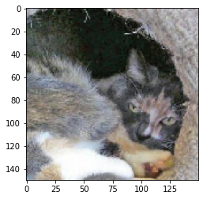

```python
# 0 for cat, 1 for dog
for data_batch, labels_batch in train_generator:
    print("data_batch:", data_batch.shape)
    print("labels_batch:", labels_batch.shape)
    print("labels:", labels_batch)
    plt.imshow(data_batch[0])
    plt.show()
    break
```

```python
checkpoint = ModelCheckpoint('vanilla_model_ver2_-{epoch:03d}-{acc:03f}-{val_acc:03f}.h5', verbose=1, monitor='val_acc',save_best_only=True, mode='auto')
history = model.fit(
    train_generator,
    steps_per_epoch=2*NSAMPLES//100, # number of times it executes until it declares epoch is over, # batchsize=100
    epochs=30,
    callbacks=[checkpoint],
    validation_data=valid_generator,
    validation_steps=NSAMPLES//100)
```

[output not shown]

```python
model = tf.keras.models.load_model('vanilla_model_ver2_-015-0.890500-0.702000.h5', custom_objects=None, compile=True, options=None)
scores = model.evaluate(test_generator)
print("%s%s: %.2f%%" % ("evaluate ",model.metrics_names[1], scores[1]*100))
```

```
evaluate acc: 70.20%
```

###### Validation accuracy: 70.2% and test accuracy: 70.2%

### Not very good for the effort we did. We can try to use data augmentation by rotating, shifting, fliping, and shearing the image.

```python
# zca_whitening: add noise to image
datagen = ImageDataGenerator(
    rotation_range=40, # between 0 and 180 degrees
    width_shift_range=0.2,
    height_shift_range=0.2,
    shear_range=0.2, # stretch in one direction
    zoom_range=0.2, # multiple in both direction
    horizontal_flip=True,
    vertical_flip=True,
    fill_mode="nearest")
```

```
/home/tt/Downloads/dogs-vs-cats//train/dog.9696.jpg
```

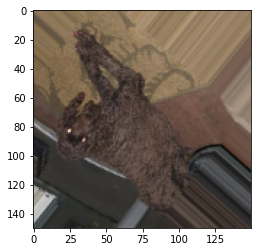

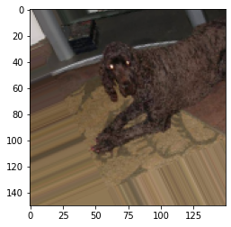

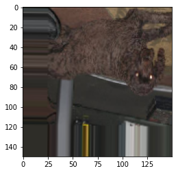

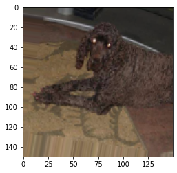

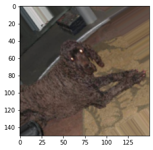

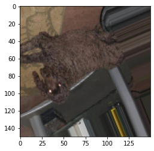

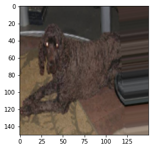

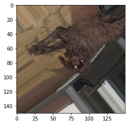

```python
# let's see some of images

from tensorflow.keras.preprocessing import image

fname = train_dogs[0]

img = image.load_img(fname, target_size=(150, 150))

plt.imshow(img)
print(fname)

x = image.img_to_array(img)
x = x.reshape((1,) + x.shape)

i = 0
for batch in datagen.flow(x, batch_size=1):
    plt.figure(i)
    imgplot = plt.imshow(image.array_to_img(batch[0]))
    i += 1
    if i % 8 == 0:
        break
plt.show()
```

### Let's see now if we can get better result.

```python
train_datagen = ImageDataGenerator(
    rescale=1./256,
    rotation_range=40,
    width_shift_range=0.2,
    height_shift_range=0.2,
    shear_range=0.2,
    zoom_range=0.2,
    horizontal_flip=True)

# Don't do any transformation on validation and test set
valid_datagen = ImageDataGenerator(rescale=1./256)
test_datagen = ImageDataGenerator(rescale=1./256)

train_generator = train_datagen.flow_from_directory(
    sampled_train_dir,
    target_size=(150,150),
    batch_size=100,
    class_mode="binary")

valid_generator = valid_datagen.flow_from_directory(
    sampled_valid_dir,
    target_size=(150,150),
    batch_size=100,
    class_mode="binary")

test_generator = test_datagen.flow_from_directory(
    sampled_test_dir,
    target_size=(150,150),
    batch_size=100,
    class_mode="binary")
```

```
Found 2000 images belonging to 2 classes.
Found 1000 images belonging to 2 classes.
Found 1000 images belonging to 2 classes.
```

```python
adam = Adam(lr=0.001)

model = get_model()

checkpoint = ModelCheckpoint('model-{epoch:03d}-{acc:03f}-{val_acc:03f}.h5', verbose=1, monitor='val_acc',save_best_only=True, mode='auto')

model.compile(loss="binary_crossentropy", optimizer=adam, metrics=["acc"])

history = model.fit_generator(
    train_generator,
    steps_per_epoch=2*NSAMPLES//100, # number of times it executes until it declares epoch is over.
    epochs=40,
    validation_data=valid_generator,
    callbacks=[checkpoint],
    validation_steps=NSAMPLES//100
)
```

```
Model: "model_2"
_________________________________________________________________
 Layer (type)                Output Shape              Param #
=================================================================
 input (InputLayer)          [(None, 150, 150, 3)]     0

 fe0 (Conv2D)                (None, 148, 148, 32)      896

 r0 (Activation)             (None, 148, 148, 32)      0

 mp0 (MaxPooling2D)          (None, 74, 74, 32)        0

 fe1 (Conv2D)                (None, 72, 72, 64)        18496

 r1 (Activation)             (None, 72, 72, 64)        0

 mp1 (MaxPooling2D)          (None, 36, 36, 64)        0

 fe2 (Conv2D)                (None, 34, 34, 128)       73856

 r2 (Activation)             (None, 34, 34, 128)       0

 mp2 (MaxPooling2D)          (None, 17, 17, 128)       0

 fl (Flatten)                (None, 36992)             0

 d5 (Dropout)                (None, 36992)             0

 d1 (Dense)                  (None, 512)               18940416

 d2 (Dense)                  (None, 1)                 513

 s1 (Activation)             (None, 1)                 0

=================================================================
Total params: 19,034,177
Trainable params: 19,034,177
Non-trainable params: 0
_________________________________________________________________
```

[output not shown]

```
Epoch 1: val_acc improved from -inf to 0.52500, saving model to model-001-0.507500-0.525000.h5
Epoch 2: val_acc improved from 0.52500 to 0.53400, saving model to model-002-0.545500-0.534000.h5
Epoch 3: val_acc improved from 0.53400 to 0.60700, saving model to model-003-0.584500-0.607000.h5
Epoch 4: val_acc improved from 0.60700 to 0.64600, saving model to model-004-0.611000-0.646000.h5
Epoch 5: val_acc did not improve from 0.64600
Epoch 6: val_acc did not improve from 0.64600
Epoch 7: val_acc did not improve from 0.64600
Epoch 8: val_acc improved from 0.64600 to 0.67200, saving model to model-008-0.655000-0.672000.h5
Epoch 9: val_acc did not improve from 0.67200
Epoch 10: val_acc did not improve from 0.67200
Epoch 11: val_acc did not improve from 0.67200
Epoch 12: val_acc improved from 0.67200 to 0.69600, saving model to model-012-0.626500-0.696000.h5
Epoch 13: val_acc did not improve from 0.69600
Epoch 14: val_acc did not improve from 0.69600
Epoch 15: val_acc did not improve from 0.69600
Epoch 16: val_acc did not improve from 0.69600
Epoch 17: val_acc did not improve from 0.69600
Epoch 18: val_acc did not improve from 0.69600
Epoch 19: val_acc did not improve from 0.69600
Epoch 20: val_acc improved from 0.69600 to 0.70400, saving model to model-020-0.650500-0.704000.h5
Epoch 21: val_acc did not improve from 0.70400
Epoch 22: val_acc improved from 0.70400 to 0.70800, saving model to model-022-0.648500-0.708000.h5
Epoch 23: val_acc did not improve from 0.70800
Epoch 24: val_acc did not improve from 0.70800
Epoch 25: val_acc did not improve from 0.70800
Epoch 26: val_acc did not improve from 0.70800
Epoch 27: val_acc did not improve from 0.70800
Epoch 28: val_acc did not improve from 0.70800
Epoch 29: val_acc did not improve from 0.70800
Epoch 30: val_acc improved from 0.70800 to 0.71800, saving model to model-030-0.672500-0.718000.h5
Epoch 31: val_acc did not improve from 0.71800
Epoch 32: val_acc improved from 0.71800 to 0.72000, saving model to model-032-0.687000-0.720000.h5
Epoch 33: val_acc improved from 0.72000 to 0.72700, saving model to model-033-0.674500-0.727000.h5
Epoch 34: val_acc did not improve from 0.72700
Epoch 35: val_acc did not improve from 0.72700
Epoch 36: val_acc improved from 0.72700 to 0.72800, saving model to model-036-0.686000-0.728000.h5
Epoch 37: val_acc did not improve from 0.72800
Epoch 38: val_acc did not improve from 0.72800
Epoch 39: val_acc did not improve from 0.72800
Epoch 40: val_acc did not improve from 0.72800
```

```python
model = tf.keras.models.load_model('model-036-0.686000-0.728000.h5', custom_objects=None, compile=True, options=None)
scores = model.evaluate(test_generator)
print("%s%s: %.2f%%" % ("evaluate ",model.metrics_names[1], scores[1]*100))
```

```
evaluate acc: 73.40%
```

##### Best validation accuracy: 72.8%, test accuracy: 73.4%

### You should run both cases and change the number of epochs to 30 or so and report the validation and test accuracy. Try also to modify the network to get higher accuracy.

# Transfer Learning

In this part of the lab, you will load VGG16 and try to get it to improve the result of this model.

When you use pretrained networks, you have to pay attention to the preprocessing requirements of the inputs.

For example, `Resnet50` requires a minimum of `(200, 200, 3)` image. Since our cats and dogs example has an image size of `(150, 150, 3)`, one possible solution is to use `UpSampling2D` layer to increase the image to `(300, 300, 3)`.

```
x = UpSampling2D(size=(2, 2))(x_input)
```

You should definitely read any pre-trained documentation before starting using it. For VGG16, you can find it at https://keras.io/api/applications/vgg/.

All frameworks come with several pretrained models, like VGG, MobileNet, ResNet, and GoogleNet.

```python
image_size = (150, 150)
```

```python
from tensorflow.keras.applications import VGG16
image_size = (150, 150)
vgg16 = VGG16(weights="imagenet", include_top=False, input_shape=(*image_size, 3))
```

```python
vgg16.summary()
```

```
Model: "vgg16"
_________________________________________________________________
 Layer (type)                Output Shape              Param #
=================================================================
 input_1 (InputLayer)        [(None, 150, 150, 3)]     0

 block1_conv1 (Conv2D)       (None, 150, 150, 64)      1792

 block1_conv2 (Conv2D)       (None, 150, 150, 64)      36928

 block1_pool (MaxPooling2D)  (None, 75, 75, 64)        0

 block2_conv1 (Conv2D)       (None, 75, 75, 128)       73856

 block2_conv2 (Conv2D)       (None, 75, 75, 128)       147584

 block2_pool (MaxPooling2D)  (None, 37, 37, 128)       0

 block3_conv1 (Conv2D)       (None, 37, 37, 256)       295168

 block3_conv2 (Conv2D)       (None, 37, 37, 256)       590080

 block3_conv3 (Conv2D)       (None, 37, 37, 256)       590080

 block3_pool (MaxPooling2D)  (None, 18, 18, 256)       0

 block4_conv1 (Conv2D)       (None, 18, 18, 512)       1180160

 block4_conv2 (Conv2D)       (None, 18, 18, 512)       2359808

 block4_conv3 (Conv2D)       (None, 18, 18, 512)       2359808

 block4_pool (MaxPooling2D)  (None, 9, 9, 512)         0

 block5_conv1 (Conv2D)       (None, 9, 9, 512)         2359808

 block5_conv2 (Conv2D)       (None, 9, 9, 512)         2359808

 block5_conv3 (Conv2D)       (None, 9, 9, 512)         2359808

 block5_pool (MaxPooling2D)  (None, 4, 4, 512)         0

=================================================================
Total params: 14,714,688
Trainable params: 14,714,688
Non-trainable params: 0
_________________________________________________________________
```

```python
# every layer or model with trainable set to false does not update weights
vgg16.trainable = False

x_i = Input((150, 150, 3), name="input")
x = vgg16(x_i)
x = GlobalAveragePooling2D()(x) #  for each channel, it average those 16 values (4, 4, 512). x=Flatten()(AveragePooling2D(4,4)(x)) will give the same result.
x = Dropout(0.5, name="drop_input_512")(x)
x = Dense(512, name="d512", activation="relu")(x)
x = Dropout(0.5, name="drop_input_100")(x)
x = Dense(100, name="d100", activation="relu")(x)
x = Dense(1, name="d2", activation="sigmoid")(x)

model = Model(inputs=x_i, outputs=x)
model.summary()
```

```
Model: "model_3"
_________________________________________________________________
 Layer (type)                Output Shape              Param #
=================================================================
 input (InputLayer)          [(None, 150, 150, 3)]     0

 vgg16 (Functional)          (None, 4, 4, 512)         14714688

 global_average_pooling2d (G  (None, 512)              0
 lobalAveragePooling2D)

 drop_input_512 (Dropout)    (None, 512)               0

 d512 (Dense)                (None, 512)               262656

 drop_input_100 (Dropout)    (None, 512)               0

 d100 (Dense)                (None, 100)               51300

 d2 (Dense)                  (None, 1)                 101

=================================================================
Total params: 15,028,745
Trainable params: 314,057
Non-trainable params: 14,714,688
_________________________________________________________________
```

Note that in this case, we are not retraining the VGG16 model, just the final dense layers. Why?

```python
# if want to get the layer before the last layer of vgg and already train, we can do this.
new_model = Model(vgg16.inputs, vgg16.get_layer('block4_conv3').output)
new_model.summary()
```

```
Model: "model_16"
_________________________________________________________________
 Layer (type)                Output Shape              Param #
=================================================================
 input_2 (InputLayer)        [(None, 150, 150, 3)]     0

 block1_conv1 (Conv2D)       (None, 150, 150, 64)      1792

 block1_conv2 (Conv2D)       (None, 150, 150, 64)      36928

 block1_pool (MaxPooling2D)  (None, 75, 75, 64)        0

 block2_conv1 (Conv2D)       (None, 75, 75, 128)       73856

 block2_conv2 (Conv2D)       (None, 75, 75, 128)       147584

 block2_pool (MaxPooling2D)  (None, 37, 37, 128)       0

 block3_conv1 (Conv2D)       (None, 37, 37, 256)       295168

 block3_conv2 (Conv2D)       (None, 37, 37, 256)       590080

 block3_conv3 (Conv2D)       (None, 37, 37, 256)       590080

 block3_pool (MaxPooling2D)  (None, 18, 18, 256)       0

 block4_conv1 (Conv2D)       (None, 18, 18, 512)       1180160

 block4_conv2 (Conv2D)       (None, 18, 18, 512)       2359808

 block4_conv3 (Conv2D)       (None, 18, 18, 512)       2359808

=================================================================
Total params: 7,635,264
Trainable params: 0
Non-trainable params: 7,635,264
_________________________________________________________________
```

```python
# new_model.get_layer('block4_conv3').get_weights()[0] # weights
```

```python
# new_model.get_layer('block4_conv3').get_weights()[1] # bias
```

```python
checkpoint = ModelCheckpoint('VGG16_model_ver2-{epoch:03d}-{acc:03f}-{val_acc:03f}.h5', verbose=1, monitor='val_acc',save_best_only=True, mode='auto')
adam = Adam(0.001) # SGD usually give better results but hard to convert
model.compile(loss="binary_crossentropy", optimizer=adam, metrics=["acc"])

history = model.fit(
    train_generator,
    steps_per_epoch=2*NSAMPLES//100, # number of times it executes until it declares epoch is over.
    epochs=40,
    validation_data=valid_generator,
    callbacks=[checkpoint],
    validation_steps=NSAMPLES//100
)
```

```
Epoch 1: val_acc improved from -inf to 0.87400, saving model to VGG16_model_ver2-001-0.793000-0.874000.h5
Epoch 2: val_acc did not improve from 0.87400
Epoch 3: val_acc did not improve from 0.87400
Epoch 4: val_acc did not improve from 0.87400
Epoch 5: val_acc improved from 0.87400 to 0.87500, saving model to VGG16_model_ver2-005-0.807000-0.875000.h5
Epoch 6: val_acc did not improve from 0.87500
Epoch 7: val_acc did not improve from 0.87500
Epoch 8: val_acc did not improve from 0.87500
Epoch 9: val_acc did not improve from 0.87500
Epoch 10: val_acc did not improve from 0.87500
Epoch 11: val_acc did not improve from 0.87500
Epoch 12: val_acc did not improve from 0.87500
Epoch 13: val_acc did not improve from 0.87500
Epoch 14: val_acc did not improve from 0.87500
Epoch 15: val_acc did not improve from 0.87500
Epoch 16: val_acc did not improve from 0.87500
Epoch 17: val_acc did not improve from 0.87500
Epoch 18: val_acc did not improve from 0.87500
Epoch 19: val_acc did not improve from 0.87500
Epoch 20: val_acc did not improve from 0.87500
Epoch 21: val_acc did not improve from 0.87500
Epoch 22: val_acc did not improve from 0.87500
Epoch 23: val_acc did not improve from 0.87500
Epoch 24: val_acc did not improve from 0.87500
Epoch 25: val_acc did not improve from 0.87500
Epoch 26: val_acc did not improve from 0.87500
Epoch 27: val_acc did not improve from 0.87500
Epoch 28: val_acc did not improve from 0.87500
Epoch 29: val_acc did not improve from 0.87500
Epoch 30: val_acc did not improve from 0.87500
Epoch 31: val_acc did not improve from 0.87500
Epoch 32: val_acc did not improve from 0.87500
Epoch 33: val_acc did not improve from 0.87500
Epoch 34: val_acc did not improve from 0.87500
Epoch 35: val_acc did not improve from 0.87500
Epoch 36: val_acc did not improve from 0.87500
Epoch 37: val_acc did not improve from 0.87500
Epoch 38: val_acc did not improve from 0.87500
Epoch 39: val_acc improved from 0.87500 to 0.88400, saving model to VGG16_model_ver2-039-0.798500-0.884000.h5
Epoch 40: val_acc did not improve from 0.88400
```

```python
model = tf.keras.models.load_model('VGG16_model_ver2-039-0.798500-0.884000.h5', custom_objects=None, compile=True, options=None)
scores = model.evaluate(test_generator)
print("%s%s: %.2f%%" % ("evaluate ", model.metrics_names[1], scores[1]*100))
```

```
evaluate acc: 88.40%
```

#### Now, you should change the model above so that the vgg16 is only run before, and you should store the features extracted by vgg16 in memory in order to train the last layers of the network.

#### Save images and responses into respective directories so that you do not need to keep applying vgg during training loop

#### In Keras, you can set "trainable" attribute for any layer or model. You should traverse vgg16, and try to set the trainable parameter to False before block5, and from block5 forward, it should be set to True.

```python
vgg16 = VGG16(weights="imagenet", include_top=False, input_shape=(150, 150, 3))

# Block 5 will be trained with initial weights are the trained weights
for l in vgg16.layers:
    if 'block5' not in l.name:
        l.trainable = False
    else:
        print(f'training layer {l.name}')

x_i = Input((150, 150, 3), name="input")
x = vgg16(x_i)
x = GlobalAveragePooling2D()(x)
x = Dropout(0.5, name="drop_input_512")(x)
x = Dense(512, name="d512", activation="relu")(x)
x = Dropout(0.5, name="drop_input_100")(x)
x = Dense(100, name="d100", activation="relu")(x)
x = Dense(1, name="d2", activation="sigmoid")(x)

model = Model(inputs=x_i, outputs=x)
model.summary()
```

```
training layer block5_conv1
training layer block5_conv2
training layer block5_conv3
training layer block5_pool
Model: "model_17"
_________________________________________________________________
 Layer (type)                Output Shape              Param #
=================================================================
 input (InputLayer)          [(None, 150, 150, 3)]     0

 vgg16 (Functional)          (None, 4, 4, 512)         14714688

 global_average_pooling2d_2   (None, 512)              0
 (GlobalAveragePooling2D)

 drop_input_512 (Dropout)    (None, 512)               0

 d512 (Dense)                (None, 512)               262656

 drop_input_100 (Dropout)    (None, 512)               0

 d100 (Dense)                (None, 100)               51300

 d2 (Dense)                  (None, 1)                 101

=================================================================
Total params: 15,028,745
Trainable params: 7,393,481
Non-trainable params: 7,635,264
_________________________________________________________________
```

```python
checkpoint = ModelCheckpoint('VGG16_block5_model-{epoch:03d}-{acc:03f}-{val_acc:03f}.h5', verbose=1, monitor='val_acc',save_best_only=True, mode='auto')
adam = Adam(0.001) # SGD usually give better results but hard to convert
model.compile(loss="binary_crossentropy", optimizer=adam, metrics=["acc"])

history = model.fit(
    train_generator,
    steps_per_epoch=2*NSAMPLES//100, # number of times it executes until it declares epoch is over.
    epochs=40,
    validation_data=valid_generator,
    callbacks=[checkpoint],
    validation_steps=NSAMPLES//100
)
```

```
Epoch 1: val_acc improved from -inf to 0.78800, saving model to VGG16_block5_model-001-0.586000-0.788000.h5
Epoch 2: val_acc improved from 0.78800 to 0.85200, saving model to VGG16_block5_model-002-0.717000-0.852000.h5
Epoch 3: val_acc improved from 0.85200 to 0.88600, saving model to VGG16_block5_model-003-0.782500-0.886000.h5
Epoch 4: val_acc did not improve from 0.88600
Epoch 5: val_acc improved from 0.88600 to 0.90000, saving model to VGG16_block5_model-005-0.853000-0.900000.h5
Epoch 6: val_acc improved from 0.90000 to 0.90600, saving model to VGG16_block5_model-006-0.873000-0.906000.h5
Epoch 7: val_acc did not improve from 0.90600
Epoch 8: val_acc improved from 0.90600 to 0.91400, saving model to VGG16_block5_model-008-0.903000-0.914000.h5
Epoch 9: val_acc improved from 0.91400 to 0.92100, saving model to VGG16_block5_model-009-0.908000-0.921000.h5
Epoch 10: val_acc did not improve from 0.92100
Epoch 11: val_acc did not improve from 0.92100
Epoch 12: val_acc did not improve from 0.92100
Epoch 13: val_acc improved from 0.92100 to 0.93300, saving model to VGG16_block5_model-013-0.928000-0.933000.h5
Epoch 14: val_acc did not improve from 0.93300
Epoch 15: val_acc did not improve from 0.93300
Epoch 16: val_acc did not improve from 0.93300
Epoch 17: val_acc did not improve from 0.93300
Epoch 18: val_acc improved from 0.93300 to 0.93400, saving model to VGG16_block5_model-018-0.941500-0.934000.h5
Epoch 19: val_acc did not improve from 0.93400
Epoch 20: val_acc did not improve from 0.93400
Epoch 21: val_acc did not improve from 0.93400
Epoch 22: val_acc improved from 0.93400 to 0.93700, saving model to VGG16_block5_model-022-0.951500-0.937000.h5
Epoch 23: val_acc did not improve from 0.93700
Epoch 24: val_acc did not improve from 0.93700
Epoch 25: val_acc did not improve from 0.93700
Epoch 26: val_acc did not improve from 0.93700
Epoch 27: val_acc did not improve from 0.93700
Epoch 28: val_acc did not improve from 0.93700
Epoch 29: val_acc did not improve from 0.93700
Epoch 30: val_acc did not improve from 0.93700
Epoch 31: val_acc did not improve from 0.93700
Epoch 32: val_acc improved from 0.93700 to 0.94300, saving model to VGG16_block5_model-032-0.962000-0.943000.h5
Epoch 33: val_acc did not improve from 0.94300
Epoch 34: val_acc did not improve from 0.94300
Epoch 35: val_acc did not improve from 0.94300
Epoch 36: val_acc did not improve from 0.94300
Epoch 37: val_acc did not improve from 0.94300
Epoch 38: val_acc did not improve from 0.94300
Epoch 39: val_acc did not improve from 0.94300
Epoch 40: val_acc did not improve from 0.94300
```

```python
model = tf.keras.models.load_model('VGG16_block5_model-032-0.962000-0.943000.h5', custom_objects=None, compile=True, options=None)
scores = model.evaluate(test_generator)
print("%s%s: %.2f%%" % ("evaluate ",model.metrics_names[1], scores[1]*100))
```

```
evaluate acc: 94.90%
```

### You should also try to use resnet50 and mobilenetv2. You will need to use the appropriate `preprocess_function` function for each of the networks.

Remember also that for resnet50, you need to use an image of `(300, 300, 3)` and to use `UpSampling2D` before invoking resnet50 block.

The documentations can be found at https://keras.io/api/applications/

### resnet code

```python
resnet50 = ResNet50(weights="imagenet", include_top=False, input_shape=(150, 150, 3))

for l in resnet50.layers:
    if ('block3' not in l.name) and ('block4' not in l.name):
        l.trainable = False

x_i = Input((150, 150, 3), name="input")
x = resnet50(x_i)
x = GlobalAveragePooling2D()(x)
x = Dropout(0.5, name="drop_input_512")(x)
x = Dense(512, name="d512", activation="relu")(x)
x = Dropout(0.5, name="drop_input_100")(x)
x = Dense(100, name="d100", activation="relu")(x)
x = Dense(1, name="d2", activation="sigmoid")(x)

model = Model(inputs=x_i, outputs=x)
model.summary()
```

```
Model: "model_21"
_________________________________________________________________
 Layer (type)                Output Shape              Param #
=================================================================
 input (InputLayer)          [(None, 150, 150, 3)]     0

 resnet50 (Functional)       (None, 5, 5, 2048)        23587712

 global_average_pooling2d_20  (None, 2048)             0
  (GlobalAveragePooling2D)

 drop_input_512 (Dropout)    (None, 2048)              0

 d512 (Dense)                (None, 512)               1049088

 drop_input_100 (Dropout)    (None, 512)               0

 d100 (Dense)                (None, 100)               51300

 d2 (Dense)                  (None, 1)                 101

=================================================================
Total params: 24,688,201
Trainable params: 8,436,041
Non-trainable params: 16,252,160
_________________________________________________________________
```

```python
checkpoint = ModelCheckpoint('VGG16_block5_model_ver2-{epoch:03d}-{acc:03f}-{val_acc:03f}.h5', verbose=1, monitor='val_acc',save_best_only=True, mode='auto')
adam = Adam(0.001) # SGD usually give better results but hard to convert
model.compile(loss="binary_crossentropy", optimizer=adam, metrics=["acc"])

history = model.fit(
    train_generator,
    steps_per_epoch=2*NSAMPLES//100, # number of times it executes until it declares epoch is over.
    epochs=40,
    validation_data=valid_generator,
    callbacks=[checkpoint],
    validation_steps=NSAMPLES//100
)
```

```
Epoch 1: val_acc improved from -inf to 0.56300, saving model to VGG16_block5_model_ver2-001-0.942500-0.563000.h5
Epoch 2: val_acc did not improve from 0.56300
Epoch 3: val_acc improved from 0.56300 to 0.63200, saving model to VGG16_block5_model_ver2-003-0.953500-0.632000.h5
Epoch 4: val_acc improved from 0.63200 to 0.81000, saving model to VGG16_block5_model_ver2-004-0.953500-0.810000.h5
Epoch 5: val_acc did not improve from 0.81000
Epoch 6: val_acc did not improve from 0.81000
Epoch 7: val_acc did not improve from 0.81000
Epoch 8: val_acc did not improve from 0.81000
Epoch 9: val_acc improved from 0.81000 to 0.86000, saving model to VGG16_block5_model_ver2-009-0.944000-0.860000.h5
Epoch 10: val_acc did not improve from 0.86000
Epoch 11: val_acc did not improve from 0.86000
Epoch 12: val_acc did not improve from 0.86000
Epoch 13: val_acc did not improve from 0.86000
Epoch 14: val_acc did not improve from 0.86000
Epoch 15: val_acc did not improve from 0.86000
Epoch 16: val_acc did not improve from 0.86000
Epoch 17: val_acc did not improve from 0.86000
Epoch 18: val_acc improved from 0.86000 to 0.89200, saving model to VGG16_block5_model_ver2-018-0.963000-0.892000.h5
Epoch 19: val_acc did not improve from 0.89200
Epoch 20: val_acc did not improve from 0.89200
Epoch 21: val_acc did not improve from 0.89200
Epoch 22: val_acc did not improve from 0.89200
Epoch 23: val_acc did not improve from 0.89200
Epoch 24: val_acc did not improve from 0.89200
Epoch 25: val_acc did not improve from 0.89200
Epoch 26: val_acc did not improve from 0.89200
Epoch 27: val_acc did not improve from 0.89200
Epoch 28: val_acc did not improve from 0.89200
Epoch 29: val_acc did not improve from 0.89200
Epoch 30: val_acc did not improve from 0.89200
Epoch 31: val_acc did not improve from 0.89200
Epoch 32: val_acc did not improve from 0.89200
Epoch 33: val_acc did not improve from 0.89200
Epoch 34: val_acc did not improve from 0.89200
Epoch 35: val_acc improved from 0.89200 to 0.89900, saving model to VGG16_block5_model_ver2-035-0.970000-0.899000.h5
Epoch 36: val_acc did not improve from 0.89900
Epoch 37: val_acc did not improve from 0.89900
Epoch 38: val_acc did not improve from 0.89900
Epoch 39: val_acc did not improve from 0.89900
Epoch 40: val_acc improved from 0.89900 to 0.91100, saving model to VGG16_block5_model_ver2-040-0.980500-0.911000.h5
```

```python
model = tf.keras.models.load_model('VGG16_block5_model_ver2-040-0.980500-0.911000.h5', custom_objects=None, compile=True, options=None)
scores = model.evaluate(test_generator)
print("%s%s: %.2f%%" % ("evaluate ",model.metrics_names[1], scores[1]*100))
```

```
evaluate acc: 91.10%
```

### mobilenetv2

```python
mobilenetv2 = MobileNetV2(weights="imagenet", include_top=False, input_shape=(150, 150, 3))
mobilenetv2.trainable = False

x_i = Input((150, 150, 3), name="input")
x = mobilenetv2(x_i)
x = GlobalAveragePooling2D()(x)
x = Dropout(0.5, name="drop_input_512")(x)
x = Dense(512, name="d512", activation="relu")(x)
x = Dropout(0.5, name="drop_input_100")(x)
x = Dense(100, name="d100", activation="relu")(x)
x = Dense(1, name="d2", activation="sigmoid")(x)

model = Model(inputs=x_i, outputs=x)
model.summary()
```

```
WARNING:tensorflow:`input_shape` is undefined or non-square, or `rows` is not in [96, 128, 160, 192, 224]. Weights for input shape (224, 224) will be loaded as the default.
Model: "model_23"
_________________________________________________________________
 Layer (type)                Output Shape              Param #
=================================================================
 input (InputLayer)          [(None, 150, 150, 3)]     0

 mobilenetv2_1.00_224 (Funct  (None, 5, 5, 1280)       2257984
 ional)

 global_average_pooling2d_22  (None, 1280)             0
  (GlobalAveragePooling2D)

 drop_input_512 (Dropout)    (None, 1280)              0

 d512 (Dense)                (None, 512)               655872

 drop_input_100 (Dropout)    (None, 512)               0

 d100 (Dense)                (None, 100)               51300

 d2 (Dense)                  (None, 1)                 101

=================================================================
Total params: 2,965,257
Trainable params: 707,273
Non-trainable params: 2,257,984
_________________________________________________________________
```

```python
checkpoint = ModelCheckpoint('mobilenetv2_model_ver2-{epoch:03d}-{acc:03f}-{val_acc:03f}.h5', verbose=1, monitor='val_acc',save_best_only=True, mode='auto')
adam = Adam(0.001) # SGD usually give better results but hard to convert
model.compile(loss="binary_crossentropy", optimizer=adam, metrics=["acc"])

history = model.fit(
    train_generator,
    steps_per_epoch=2*NSAMPLES//100, # number of times it executes until it declares epoch is over.
    epochs=40,
    validation_data=valid_generator,
    callbacks=[checkpoint],
    validation_steps=NSAMPLES//100
)
```

```
Epoch 1: val_acc improved from -inf to 0.93300, saving model to mobilenetv2_model_ver2-001-0.721000-0.933000.h5
Epoch 2: val_acc did not improve from 0.93300
Epoch 3: val_acc improved from 0.93300 to 0.93600, saving model to mobilenetv2_model_ver2-003-0.884000-0.936000.h5
Epoch 4: val_acc improved from 0.93600 to 0.93900, saving model to mobilenetv2_model_ver2-004-0.889000-0.939000.h5
Epoch 5: val_acc did not improve from 0.93900
Epoch 6: val_acc improved from 0.93900 to 0.94800, saving model to mobilenetv2_model_ver2-006-0.891500-0.948000.h5
Epoch 7: val_acc did not improve from 0.94800
Epoch 8: val_acc improved from 0.94800 to 0.94900, saving model to mobilenetv2_model_ver2-008-0.892500-0.949000.h5
Epoch 9: val_acc did not improve from 0.94900
Epoch 10: val_acc did not improve from 0.94900
Epoch 11: val_acc improved from 0.94900 to 0.95000, saving model to mobilenetv2_model_ver2-011-0.900500-0.950000.h5
Epoch 12: val_acc did not improve from 0.95000
Epoch 13: val_acc did not improve from 0.95000
Epoch 14: val_acc improved from 0.95000 to 0.95100, saving model to mobilenetv2_model_ver2-014-0.911000-0.951000.h5
Epoch 15: val_acc did not improve from 0.95100
Epoch 16: val_acc did not improve from 0.95100
Epoch 17: val_acc did not improve from 0.95100
Epoch 18: val_acc did not improve from 0.95100
Epoch 19: val_acc did not improve from 0.95100
Epoch 20: val_acc did not improve from 0.95100
Epoch 21: val_acc did not improve from 0.95100
Epoch 22: val_acc did not improve from 0.95100
Epoch 23: val_acc did not improve from 0.95100
Epoch 24: val_acc did not improve from 0.95100
Epoch 25: val_acc did not improve from 0.95100
Epoch 26: val_acc did not improve from 0.95100
Epoch 27: val_acc did not improve from 0.95100
Epoch 28: val_acc did not improve from 0.95100
Epoch 29: val_acc did not improve from 0.95100
Epoch 30: val_acc did not improve from 0.95100
Epoch 31: val_acc did not improve from 0.95100
Epoch 32: val_acc did not improve from 0.95100
Epoch 33: val_acc improved from 0.95100 to 0.95600, saving model to mobilenetv2_model_ver2-033-0.911500-0.956000.h5
Epoch 34: val_acc did not improve from 0.95600
Epoch 35: val_acc did not improve from 0.95600
Epoch 36: val_acc did not improve from 0.95600
Epoch 37: val_acc did not improve from 0.95600
Epoch 38: val_acc did not improve from 0.95600
Epoch 39: val_acc did not improve from 0.95600
Epoch 40: val_acc did not improve from 0.95600
```

```python
model = tf.keras.models.load_model('mobilenetv2_model_ver2-033-0.911500-0.956000.h5', custom_objects=None, compile=True, options=None)
scores = model.evaluate(test_generator)
print("%s%s: %.2f%%" % ("evaluate ",model.metrics_names[1], scores[1]*100))
```

```
evaluate acc: 95.60%
```

# Hyperparameter Tuning Using KerasTuner

In this lab, you will perform hyperparameter tuning using KerasTuner.

You will fine tune a model to try to outperform other models.

To install keras tuner, you need to do.

```
pip3 install keras-tuner
```

```python
# # you may need to uninstall and reinstall protobuffer to get the latest version of keras tuner.

# !yes | pip3 uninstall protobuf python3-protobuf
# !pip3 install --upgrade protobuf
# !pip3 install keras-tuner --upgrade
```

```python
from tensorflow import keras
import keras_tuner as kt
```

```python
(img_train, label_train), (img_test, label_test) = keras.datasets.fashion_mnist.load_data()

# Normalize pixel values between 0 and 1
img_train = img_train.astype('float32') / 255.0
img_test = img_test.astype('float32') / 255.0
```

```python
def model_builder(hp):
  model = keras.Sequential()
  model.add(keras.layers.Flatten(input_shape=(28, 28)))

  # Tune the number of units in the first Dense layer
  # Choose an optimal value between 32-512

  # 8 x 6 x 3 x 3 ~ 500 options

  for i in range(hp.Int('layers', 3, 10)): # try number of layers between 3 and 10
        model.add(tf.keras.layers.Dense(
            units=hp.Int('units_' + str(i), 50, 100, step=10),
            activation=hp.Choice('act_' + str(i), ['relu', 'swish', 'tanh'])))
        if hp.Boolean('will_use_dropout_' + str(i)):
            model.add(tf.keras.layers.Dropout(0.3))
  model.add(keras.layers.Dense(10))

  # Tune the learning rate for the optimizer
  # Choose an optimal value from 0.01, 0.001, or 0.0001
  hp_learning_rate = hp.Choice('learning_rate', values = [1e-2, 1e-3, 1e-4])

  model.compile(optimizer = keras.optimizers.Adam(learning_rate = hp_learning_rate),
                loss = keras.losses.SparseCategoricalCrossentropy(from_logits = True),
                metrics = ['accuracy'])

  return model
```

```python
# do random try with maximum 30 try
import tensorflow as tf
mode = 'random'
keras_tuner_dir = 'kt_dir'

try:
    shutil.rmtree(keras_tuner_dir)
except:
    pass

if mode == 'hyperband':
    tuner = kt.Hyperband(
        model_builder,
        objective = 'val_accuracy',
        max_epochs = 10,
        factor = 3,
        directory = keras_tuner_dir,
        project_name = 'intro_to_kt_hyperband')
else:
    tuner = kt.RandomSearch(
        model_builder,
        objective='val_accuracy',
        max_trials=30,
        executions_per_trial=1,
        directory=keras_tuner_dir,
        project_name='intro_kt_random')
```

```python
tuner.search(
    img_train, label_train,
    batch_size=64,
    epochs = 5,
    validation_data = (img_test, label_test),
    callbacks = [])
```

```
Trial 30 Complete [00h 00m 06s]
val_accuracy: 0.8514999747276306

Best val_accuracy So Far: 0.873199999332428
Total elapsed time: 00h 04m 01s
INFO:tensorflow:Oracle triggered exit
```

```python
# Get the optimal hyperparameters
best_hps = tuner.get_best_hyperparameters(num_trials = 1)[0]

n_layers = best_hps.get('layers')
print(n_layers)
print()
for i in range(n_layers):
    print(best_hps.get('units_' + str(i)), best_hps.get('act_' + str(i)))
print(best_hps.get('learning_rate'))
```

```
5

90 swish
80 swish
100 tanh
80 relu
100 swish
0.001
```

Keras tuner has three optimizers.

- RandomSearch
- BayesianOptimization (Gaussian Processes)
- Hyperband

In the code, we showed how to start random search and hyperband.

Usually, you use the following parameters in Keras Tuner.

- hp.Boolean
- hp.Int
- hp.Float
- hp.Choice
- hp.Fixed
- hp.Float
- Conditional scope

You can find more information in https://keras-team.github.io/keras-tuner/

### Now you can tune your VGG network from Section 1 to see which model will get the best performance.

```python
vgg16 = VGG16(weights="imagenet", include_top=False, input_shape=(150, 150, 3))
vgg16.trainable = False

def model_builder(hp):
    model = keras.Sequential()
    model.add(vgg16)
    model.add(GlobalAveragePooling2D())

    for i in range(hp.Int('layers', 2, 10)): # try number of layers between 3 and 10
        model.add(Dense(units=hp.Int('units_' + str(i), 100, 600, step=10),
            activation=hp.Choice('act_' + str(i), ['relu', 'swish', 'tanh'])))
        model.add(Dropout(rate=hp.Choice('dropout', values=[0.3, 0.5, 0.7])))
    model.add(keras.layers.Dense(1))

    # Tune the learning rate for the optimizer
    # Choose an optimal value from 0.01, 0.001, or 0.0001
    hp_learning_rate = hp.Choice('learning_rate', values = [1e-2, 1e-3, 1e-4])

    model.compile(optimizer = keras.optimizers.Adam(learning_rate = hp_learning_rate),
                loss = keras.losses.BinaryCrossentropy(),
                metrics = ['accuracy'])

    return model
```

```python
# do random try with maximum 30 try
import tensorflow as tf
mode = 'random'
keras_tuner_dir = 'kt_dir'

try:
    shutil.rmtree(keras_tuner_dir)
except:
    pass

if mode == 'hyperband':
    tuner = kt.Hyperband(
        model_builder,
        objective = 'val_accuracy',
        max_epochs = 30,
        factor = 3,
        directory = keras_tuner_dir,
        project_name = 'intro_to_kt_hyperband')
else:
    tuner = kt.RandomSearch(
        model_builder,
        objective='val_accuracy',
        max_trials=30,
        executions_per_trial=1,
        directory=keras_tuner_dir,
        project_name='intro_kt_random')
```

```python
img_train, label_train = train_generator.next()
img_valid, label_valid = valid_generator.next()
tuner.search(
    img_train, label_train,
    batch_size=100,
    epochs = 10,
    validation_data = (img_valid, label_valid),
    callbacks = [])
```

```
Trial 30 Complete [00h 00m 03s]
val_accuracy: 0.5899999737739563

Best val_accuracy So Far: 0.8299999833106995
Total elapsed time: 00h 01m 42s
INFO:tensorflow:Oracle triggered exit
```

```python
# Get the optimal hyperparameters
best_hps = tuner.get_best_hyperparameters(num_trials = 1)[0]

n_layers = best_hps.get('layers')
print(n_layers)
print()
for i in range(n_layers):
    print(best_hps.get('units_' + str(i)), best_hps.get('act_' + str(i)))
    print(best_hps.get('dropout'))
print(best_hps.get('learning_rate'))
```

```
2

510 swish
0.7
460 tanh
0.7
0.001
```

```python
# Rebuild model with optimal hyperparameters
vgg16 = VGG16(weights="imagenet", include_top=False, input_shape=(150, 150, 3))
vgg16.trainable = False
x_i = Input((150, 150, 3), name="input")
x = vgg16(x_i)
x = GlobalAveragePooling2D()(x)
x = Dense(510, name="d600", activation="swish")(x)
x = Dropout(0.7, name="drop_input_100")(x)
x = Dense(460, name="d290", activation="tanh")(x)
x = Dropout(0.7)(x)
x = Dense(1, name="d2", activation="sigmoid")(x)

model = Model(inputs=x_i, outputs=x)
model.summary()
```

```
Model: "model"
_________________________________________________________________
 Layer (type)                Output Shape              Param #
=================================================================
 input (InputLayer)          [(None, 150, 150, 3)]     0

 vgg16 (Functional)          (None, 4, 4, 512)         14714688

 global_average_pooling2d_3   (None, 512)              0
 (GlobalAveragePooling2D)

 d600 (Dense)                (None, 510)               261630

 drop_input_100 (Dropout)    (None, 510)               0

 d290 (Dense)                (None, 460)               235060

 dropout_14 (Dropout)        (None, 460)               0

 d2 (Dense)                  (None, 1)                 461

=================================================================
Total params: 15,211,839
Trainable params: 497,151
Non-trainable params: 14,714,688
_________________________________________________________________
```

```python
# kt_model = tuner.hypermodel.build(best_hps)
checkpoint = ModelCheckpoint('keras_tuner_model_ver3-{epoch:03d}-{accuracy:03f}-{val_accuracy:03f}.h5', verbose=1, monitor='val_accuracy',save_best_only=True, mode='auto')
adam = Adam(0.001)
model.compile(loss="binary_crossentropy", optimizer=adam, metrics=["accuracy"])

history = model.fit(
    train_generator,
    steps_per_epoch=2*NSAMPLES//100, # number of times it executes until it declares epoch is over.
    epochs=40,
    validation_data=valid_generator,
    callbacks=[checkpoint],
    validation_steps=NSAMPLES//100
)
```

```
Epoch 1: val_accuracy improved from -inf to 0.88200, saving model to keras_tuner_model_ver3-001-0.857500-0.882000.h5
Epoch 2: val_accuracy improved from 0.88200 to 0.88900, saving model to keras_tuner_model_ver3-002-0.850500-0.889000.h5
Epoch 3: val_accuracy did not improve from 0.88900
Epoch 4: val_accuracy did not improve from 0.88900
Epoch 5: val_accuracy did not improve from 0.88900
Epoch 6: val_accuracy did not improve from 0.88900
Epoch 7: val_accuracy did not improve from 0.88900
Epoch 8: val_accuracy did not improve from 0.88900
Epoch 9: val_accuracy improved from 0.88900 to 0.89200, saving model to keras_tuner_model_ver3-009-0.860000-0.892000.h5
Epoch 10: val_accuracy did not improve from 0.89200
Epoch 11: val_accuracy improved from 0.89200 to 0.89400, saving model to keras_tuner_model_ver3-011-0.847500-0.894000.h5
Epoch 12: val_accuracy did not improve from 0.89400
Epoch 13: val_accuracy did not improve from 0.89400
Epoch 14: val_accuracy did not improve from 0.89400
Epoch 15: val_accuracy did not improve from 0.89400
Epoch 16: val_accuracy did not improve from 0.89400
Epoch 17: val_accuracy did not improve from 0.89400
Epoch 18: val_accuracy did not improve from 0.89400
Epoch 19: val_accuracy did not improve from 0.89400
Epoch 20: val_accuracy did not improve from 0.89400
Epoch 21: val_accuracy did not improve from 0.89400
Epoch 22: val_accuracy did not improve from 0.89400
Epoch 23: val_accuracy did not improve from 0.89400
Epoch 24: val_accuracy did not improve from 0.89400
Epoch 25: val_accuracy did not improve from 0.89400
Epoch 26: val_accuracy did not improve from 0.89400
Epoch 27: val_accuracy did not improve from 0.89400
Epoch 28: val_accuracy did not improve from 0.89400
Epoch 29: val_accuracy did not improve from 0.89400
Epoch 30: val_accuracy did not improve from 0.89400
Epoch 31: val_accuracy did not improve from 0.89400
Epoch 32: val_accuracy did not improve from 0.89400
Epoch 33: val_accuracy did not improve from 0.89400
Epoch 34: val_accuracy did not improve from 0.89400
Epoch 35: val_accuracy did not improve from 0.89400
Epoch 36: val_accuracy did not improve from 0.89400
Epoch 37: val_accuracy did not improve from 0.89400
Epoch 38: val_accuracy did not improve from 0.89400
Epoch 39: val_accuracy did not improve from 0.89400
Epoch 40: val_accuracy did not improve from 0.89400
```

```python
model = tf.keras.models.load_model('keras_tuner_model_ver3-011-0.847500-0.894000.h5', custom_objects=None, compile=True, options=None)
scores = model.evaluate(test_generator)
print("%s%s: %.2f%%" % ("evaluate ",model.metrics_names[1], scores[1]*100))
```

```
evaluate accuracy: 89.50%
```